# R Notebook

The goal here is instead of assuming everything is a power law, I’ll use a gam to interpolate each size bin. Then we do the generally same analysis.

```r
library(tidyverse)
library(tidyselect)
pass <- function(x){x}
#source("Remin_Library.R")
source("ModelStuff.R")
```

Data from elsewhere

```r
options(readr.default_locale=readr::locale(tz="Mexico/General"))
source("UVP_2017_library.R")

ES01 <- read_csv("dataOut/binned_EachSize.csv") %>% filter(depth <= 1000)
DS01 <- read_csv("dataOut/binned_DepthSummary.csv") %>% filter(depth <= 1000)
twinS <- list(ES01, DS01)
```

```r
SimpleBins <- seq(from = 0, to = 1100, by = 50) # Modified the By

#debug(bin_depths)
#binnedS <- bin_depths(twinS, bins = SimpleBins) %>% calc_psd
binnedS <- bin_depths(twinS, bins = BianchiBins) %>% calc_psd

ESS <- binnedS[[1]]
DSS <- binnedS[[2]]
```

24 November 2020

```r
# I think I want to family gamma this if it goes negative; or maybe bust poisson back out



S43data <- ESS %>% filter(profile == "stn_043")

S43GAM2X <- S43data %>% my_double_gam
summary(S43GAM2X)
```

```
Family: Negative Binomial(3.76)
Link function: log

Formula:
TotalParticles ~ s(log(lb), log(depth), by = factor(profile))

Parametric coefficients:
            Estimate Std. Error z value Pr(>|z|)
(Intercept)  -5.2717     0.3372  -15.63   <2e-16 ***
---
Signif. codes:  0 ‘***’ 0.001 ‘**’ 0.01 ‘*’ 0.05 ‘.’ 0.1 ‘ ’ 1

Approximate significance of smooth terms:
                                              edf Ref.df Chi.sq p-value
s(log(lb),log(depth)):factor(profile)stn_043 20.3  22.86   9132  <2e-16 ***
---
Signif. codes:  0 ‘***’ 0.001 ‘**’ 0.01 ‘*’ 0.05 ‘.’ 0.1 ‘ ’ 1

R-sq.(adj) =  0.904   Deviance explained = 98.6%
-REML = 1646.2  Scale est. = 1         n = 625
```

```r
S43dataEx <- expand_with_gam(S43data, S43GAM2X)
```

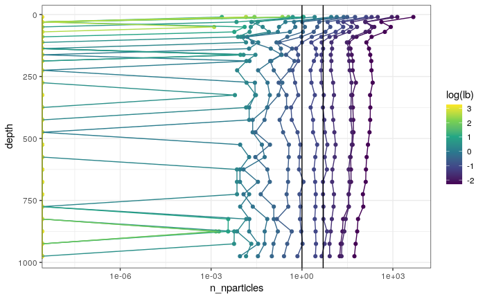

```r
nnp_size_ggplot_2d(S43dataEx)
```

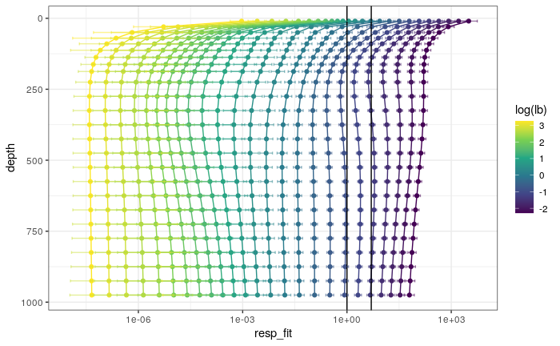

```r
gam_size_ggplot_2d(S43dataEx)
```

Order of operations (1) recalculate things that need to be recalculated (like flux and what not) (2) calculate disaggregation

# Recalculating

I should make the following code blocks into one function…

```r
S43Smooth <- S43dataEx %>%
  select(profile:vol, depth, n_nparticles = resp_fit) %>%
  mutate(nparticles = n_nparticles * binsize, TotalParticles = nparticles * vol, project = "ETNP")

S43Twin <- S43Smooth %>% make_twin_df_list() %>%
  calc_particle_parameters()

Esmooth42 <- S43Twin[[1]]
Dsmooth42 <- S43Twin[[2]]
```

```r
specData42 <- Esmooth42 %>% select(profile, depth, lb, nparticles, n_nparticles, flux_fit) %>%
  #mutate(sizeFlux = nnp * C_f_global * lb_vec * ag_global) %>%
  nest(spec_meta = c(lb, nparticles, n_nparticles, flux_fit))
```

```r
Dsmooth42_prepaired <- Dsmooth42 %>% left_join(specData42, by = c("profile", "depth")) %>%
   mutate(spec_only = map(spec_meta, ~pull(., nparticles))) %>%
  # mutate(flux2 = map(spec_meta, ~summarize(., flux3 = sum(sizeFlux)))) %>%
  mutate(spec_prev = lag(spec_only),
         flux_prev = lag(tot_flux),
         DF = flux_prev - tot_flux,
         DFP = 1 - DF/flux_prev
         )
```

```r
shuffle_tune(Dsmooth42_prepaired$DFP[[5]], Dsmooth42_prepaired$spec_only[[5]], Dsmooth42_prepaired$DFP[[5]])
```

```
[1] NaN
```

```r
# debugging
Dsmooth42_prepaired$DFP[[5]]
```

```
[1] 0.6866159
```

```r
optFun(Dsmooth42_prepaired$spec_only[[5]], Dsmooth42_prepaired$DFP[[5]])
```

[output not shown]

```
[1] 1.999959
```

```r
# debugging
shuffle_tune(optFun(Dsmooth42_prepaired$spec_only[[5]], Dsmooth42_prepaired$DFP[[5]]), Dsmooth42_prepaired$spec_only[[5]], Dsmooth42_prepaired$DFP[[5]])
```

[output not shown]

```
[1] NaN
```

```r
remin_smooth_shuffle(Dsmooth42_prepaired$spec_only[[5]], optFun(Dsmooth42_prepaired$spec_only[[5]], Dsmooth42_prepaired$DFP[[5]]))
```

[output not shown]

```
 [1] 4.002949e+01 6.951196e+00 3.771138e+00 1.976584e+00 1.114471e+00
 [6] 5.895900e-01 3.626214e-01 2.027594e-01 1.130890e-01 5.336906e-02
[11] 2.588719e-02 9.993430e-03 3.584201e-03 1.377829e-03 5.697142e-04
[16] 2.716760e-04 1.470695e-04 9.319750e-05 6.170015e-05 3.852074e-05
[21] 2.223132e-05 1.070763e-05 4.520804e-06 1.992839e-06 8.100141e-07
```

```r
remin_smooth_shuffle(Dsmooth42_prepaired$spec_only[[5]], Dsmooth42_prepaired$DFP[[5]])
```

```
 [1] 1.900339e+00 1.958754e+00 1.214876e+00 7.520373e-01 4.650512e-01
 [6] 2.888231e-01 1.783794e-01 1.066682e-01 5.938779e-02 3.002124e-02
[11] 1.416429e-02 5.874531e-03 2.272494e-03 9.252598e-04 4.127989e-04
[16] 2.102239e-04 1.215481e-04 7.893203e-05 5.260986e-05 3.298416e-05
[21] 1.884411e-05 9.156767e-06 3.949237e-06 1.744235e-06 6.775086e-07
```

```r
Dsmooth42_fixDFP <- Dsmooth42_prepaired %>%
  mutate(use_this_DFP = map2_dbl(spec_prev, DFP, optFun))
```

[output not shown]

Testing what is going on with these spectra

```r
testDepth = 137.5
test_prev <- Dsmooth42_fixDFP %>% filter(depth == testDepth) %>% pull(spec_prev) %>% .[[1]]
test_spec <- Dsmooth42_fixDFP %>% filter(depth == testDepth) %>% pull(spec_only) %>% .[[1]]
test_DFP <- Dsmooth42_fixDFP %>% filter(depth == testDepth) %>% pull(DFP)
test_use_DFP <- Dsmooth42_fixDFP %>% filter(depth == testDepth) %>% pull(use_this_DFP)
test_spec
```

```
 [1] 4.506047e+00 2.461467e+00 1.301898e+00 6.713991e-01 3.539349e-01
 [6] 1.911198e-01 1.137052e-01 6.809471e-02 4.083708e-02 2.234738e-02
[11] 1.179848e-02 5.108271e-03 1.957378e-03 7.531199e-04 3.015764e-04
[16] 1.354841e-04 6.943405e-05 4.180879e-05 2.696655e-05 1.691960e-05
[21] 9.919595e-06 4.914957e-06 2.123639e-06 9.318592e-07 3.620313e-07
```

```r
test_DFP
```

```
[1] 0.7940204
```

```r
test_use_DFP
```

```
[1] 1.999959
```

```r
test_shuf <- remin_smooth_shuffle(test_prev, test_use_DFP)
test_shuf
```

```
 [1] 3.045588e+01 5.561245e+00 2.871907e+00 1.419980e+00 7.500267e-01
 [6] 3.804580e-01 2.292785e-01 1.306977e-01 7.671565e-02 3.880190e-02
[11] 2.009332e-02 8.145165e-03 2.972596e-03 1.125427e-03 4.473756e-04
[16] 2.024536e-04 1.041960e-04 6.354250e-05 4.120884e-05 2.561855e-05
[21] 1.484326e-05 7.178598e-06 3.024558e-06 1.319860e-06 5.276405e-07
```

```r
optFun(test_prev, test_DFP)
```

[output not shown]

```
[1] 1.999959
```

```r
shuffle_tune(test_use_DFP, test_prev, test_DFP)
```

```
[1] NaN
```

```r
sum(test_prev * C_f_global * lb_vec ^ ag_global)
```

```
[1] 50.3077
```

```r
sum(test_spec * C_f_global * lb_vec ^ ag_global)
```

```
[1] 39.94534
```

```r
sum(test_shuf * C_f_global * lb_vec ^ ag_global)
```

```
[1] 109.4624
```

test shuf’s flux should equal test_spec’s flux…

```r
Dsmooth42_remineralized <- Dsmooth42_fixDFP %>% .[-1,] %>%
  mutate(spec_pred = map2(spec_prev, use_this_DFP, remin_smooth_shuffle))
```

Runs as written. Lets do calcs later.

```r
Dsmooth42_concise <- Dsmooth42_remineralized %>%
  mutate(spec_meta = map2(spec_meta, spec_prev, ~tibble(.x, np_prev = .y))) %>%
  mutate(spec_meta = map2(spec_meta, spec_pred, ~tibble(.x, np_pred = .y))) %>%
  select(profile, time, depth, DF, DFP, spec_meta)
Dsmooth42_unnest <- Dsmooth42_concise %>% unnest(spec_meta)
Dsmooth42_unnest
```

| project | profile | time | depth | DF | DFP | lb | nparticles | n_nparticles | flux_fit | np_prev | np_pred |
| --- | --- | --- | --- | --- | --- | --- | --- | --- | --- | --- | --- |
| ETNP | stn_043 | 2017-01-13 11:51:31 | 30.0 | 99.6507845600 | 0.02700397 | 0.102 | 2.136826e+01 | 8.218562e+02 | 29.56794689 | 8.264649e+01 | 8.640531e+03 |
| ETNP | stn_043 | 2017-01-13 11:51:31 | 30.0 | 99.6507845600 | 0.02700397 | 0.128 | 1.411430e+01 | 4.277060e+02 | 30.75607475 | 5.355699e+01 | 2.092688e+02 |
| ETNP | stn_043 | 2017-01-13 11:51:31 | 30.0 | 99.6507845600 | 0.02700397 | 0.161 | 9.407336e+00 | 2.239842e+02 | 32.43172420 | 3.533154e+01 | 1.289145e+02 |
| ETNP | stn_043 | 2017-01-13 11:51:31 | 30.0 | 99.6507845600 | 0.02700397 | 0.203 | 6.141915e+00 | 1.158852e+02 | 33.66258831 | 2.324213e+01 | 6.196041e+01 |
| ETNP | stn_043 | 2017-01-13 11:51:31 | 30.0 | 99.6507845600 | 0.02700397 | 0.256 | 3.904266e+00 | 5.827262e+01 | 34.03070439 | 1.534462e+01 | 4.346223e+01 |
| ETNP | stn_043 | 2017-01-13 11:51:31 | 30.0 | 99.6507845600 | 0.02700397 | 0.323 | 2.308314e+00 | 2.781102e+01 | 32.02960977 | 9.861537e+00 | 2.041252e+01 |
| ETNP | stn_043 | 2017-01-13 11:51:31 | 30.0 | 99.6507845600 | 0.02700397 | 0.406 | 1.331528e+00 | 1.256159e+01 | 29.19134425 | 6.555327e+00 | 1.462242e+01 |
| ETNP | stn_043 | 2017-01-13 11:51:31 | 30.0 | 99.6507845600 | 0.02700397 | 0.512 | 6.908970e-01 | 5.194714e+00 | 24.08822811 | 4.227197e+00 | 7.900077e+00 |
| ETNP | stn_043 | 2017-01-13 11:51:31 | 30.0 | 99.6507845600 | 0.02700397 | 0.645 | 3.367011e-01 | 2.004173e+00 | 18.63011832 | 2.771364e+00 | 5.233217e+00 |
| ETNP | stn_043 | 2017-01-13 11:51:31 | 30.0 | 99.6507845600 | 0.02700397 | 0.813 | 1.510165e-01 | 7.295485e-01 | 13.27569457 | 1.808106e+00 | 2.680568e+00 |

[output cut: 590 more lines]

Examine change

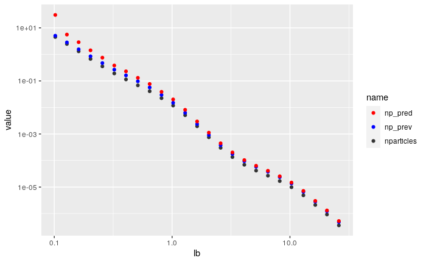

```r
DSUPlot <- Dsmooth42_unnest %>% filter(depth == testDepth) %>% ungroup() %>% select(lb, nparticles, np_prev, np_pred) %>% pivot_longer(cols = c(nparticles, np_prev, np_pred)) %>%
  ggplot(aes(x = lb, y = value, col = name)) + geom_point() + scale_x_log10() + scale_y_log10() + scale_color_manual(values = c("red", "blue", "gray20"))

DSUPlot
```

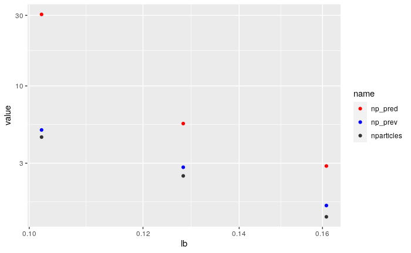

```r
Dsmooth42_unnest %>% filter(depth == testDepth, lb < 0.2) %>% ungroup() %>% select(lb, nparticles, np_prev, np_pred) %>% pivot_longer(cols = c(nparticles, np_prev, np_pred)) %>%
  ggplot(aes(x = lb, y = value, col = name)) + geom_point() + scale_x_log10() + scale_y_log10() + scale_color_manual(values = c("red", "blue", "gray20"))
```

```r
# Dsmooth42_unnest %>% filter(depth == 625) %>% ungroup() %>% select(lb, nparticles, np_prev, np_pred) %>% pivot_longer(cols = c(nparticles, np_prev, np_pred)) %>%
#   ggplot(aes(x = lb, y = value, col = name)) + geom_point(alpha = 0.75, size = 1) + scale_x_log10() + scale_y_log10() + scale_color_manual(values = c("red", "blue", "gray20"))
```

This doesn’t look right.

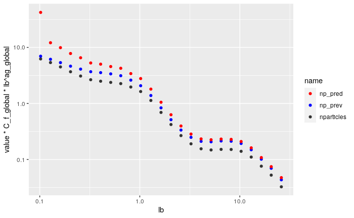

```r
f_vec = C_f_global * lb_vec ^ ag_global

Dsmooth42_unnest %>% filter(depth == testDepth) %>% ungroup() %>% select(lb, nparticles, np_prev, np_pred) %>% pivot_longer(cols = c(nparticles, np_prev, np_pred)) %>%
  ggplot(aes(x = lb, y = value * C_f_global * lb  ^ ag_global, col = name)) + geom_point() + scale_x_log10() + scale_y_log10() + scale_color_manual(values = c("red", "blue", "gray20"))
```

```r
# what is going on with my keyboard
Dsmooth42_sr02 <- Dsmooth42_unnest %>%
  mutate(flux_prev = np_prev * f_vec,
         flux_pred = np_pred * f_vec,
         flux2 = nparticles * f_vec)
Dsmooth42_sr02_Tot <- Dsmooth42_sr02 %>% group_by(depth) %>%
  summarize(DF = first(DF), DFP = first(DFP),
            Flux = sum(flux2), Flux_Prev = sum(flux_prev), Flux_Pred = sum(flux_pred))
Dsmooth42_sr02_Small <- Dsmooth42_sr02 %>%
  filter(lb <= 0.53) %>%
  group_by(depth) %>%
  summarize(Flux = sum(flux2), Flux_Prev = sum(flux_prev), Flux_Pred = sum(flux_pred))

Dsmooth42_sr02_Big <- Dsmooth42_sr02 %>%
  filter(lb > 0.53) %>%
  group_by(depth) %>%
  summarize(Flux = sum(flux2), Flux_Prev = sum(flux_prev), Flux_Pred = sum(flux_pred))

Dsmooth42_sr02_All <- Dsmooth42_sr02_Tot %>%
  left_join(Dsmooth42_sr02_Small, by = "depth", suffix = c("", "_Small")) %>%
  left_join(Dsmooth42_sr02_Big, by = "depth", suffix = c("", "_Big"))  %>%
  mutate(osps = Flux_Small - Flux_Pred_Small, Disag = osps/DF) %>%
  mutate(obpb = Flux_Pred_Big - Flux_Big) # should equal osps, but doesn't
```

```r
Dsmooth42_sr02_All
```

| depth | DF | DFP | Flux | Flux_Prev | Flux_Pred | Flux_Small | Flux_Prev_Small | Flux_Pred_Small | Flux_Big | Flux_Prev_Big | Flux_Pred_Big | osps | Disag | obpb |
| --- | --- | --- | --- | --- | --- | --- | --- | --- | --- | --- | --- | --- | --- | --- |
| 30.0 | 99.6507845600 | 0.02700397 | 367.83151 | 13621.38586 | 29503.64422 | 245.75822 | 1041.93571 | 14454.29130 | 122.073291 | 12579.450144 | 15049.352912 | -14208.53308 | -142.5833 | 1.492728e+04 |
| 50.0 | 1.5241341024 | 0.44890574 | 165.12168 | 367.83151 | 806.09715 | 127.92272 | 245.75822 | 652.93814 | 37.198953 | 122.073291 | 153.159003 | -525.01542 | -344.4680 | 1.159601e+02 |
| 70.0 | 0.4924175194 | 0.60337412 | 99.63015 | 165.12168 | 361.84151 | 76.73878 | 127.92272 | 312.15407 | 22.891362 | 37.198953 | 49.687443 | -235.41529 | -478.0806 | 2.679608e+01 |
| 90.0 | 0.2347556926 | 0.68661587 | 68.40764 | 99.63015 | 217.84264 | 51.73931 | 76.73878 | 187.21879 | 16.668329 | 22.891362 | 30.623857 | -135.47948 | -577.1084 | 1.395553e+01 |
| 112.5 | 0.1360898015 | 0.73541049 | 50.30770 | 68.40764 | 149.20170 | 37.78693 | 51.73931 | 127.28558 | 12.520762 | 16.668329 | 21.916119 | -89.49865 | -657.6441 | 9.395357e+00 |
| 137.5 | 0.0779124721 | 0.79402040 | 39.94534 | 50.30770 | 109.46237 | 30.37081 | 37.78693 | 93.34453 | 9.574531 | 12.520762 | 16.117844 | -62.97372 | -808.2624 | 6.543313e+00 |
| 162.5 | 0.0402820189 | 0.86587900 | 34.58783 | 39.94534 | 86.75091 | 26.95469 | 30.37081 | 74.64870 | 7.633137 | 9.574531 | 12.102207 | -47.69401 | -1184.0024 | 4.469070e+00 |
| 187.5 | 0.0205681762 | 0.92090953 | 31.85226 | 34.58783 | 75.03068 | 25.53033 | 26.95469 | 65.49566 | 6.321935 | 7.633137 | 9.535016 | -39.96534 | -1943.0666 | 3.213082e+00 |
| 225.0 | 0.0117531826 | 0.95092426 | 30.28909 | 31.85226 | 69.06065 | 25.19959 | 25.53033 | 61.21432 | 5.089500 | 6.321935 | 7.846337 | -36.01473 | -3064.2533 | 2.756837e+00 |
| 275.0 | -0.0003326532 | 1.00146069 | 30.33333 | 30.28909 | 65.67365 | 26.10682 | 25.19959 | 59.37414 | 4.226511 | 5.089500 | 6.299511 | -33.26732 | 100006.0301 | 2.073000e+00 |

[output cut: 14 more lines]

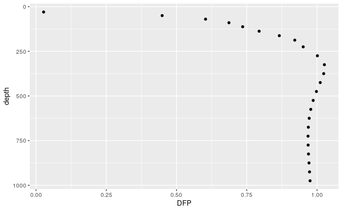

```r
Dsmooth42_sr02_All %>% ggplot(aes(x = DFP, y = depth)) + scale_y_reverse() + geom_point()
```

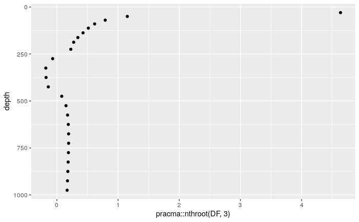

```r
Dsmooth42_sr02_All %>% #filter(DFP <= 1) %>%
  ggplot(aes(y = depth, x = pracma::nthroot(DF, 3))) + geom_point() +
  scale_y_reverse()
```

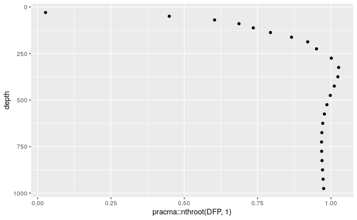

```r
Dsmooth42_sr02_All %>% #filter(DFP <= 1) %>%
  ggplot(aes(y = depth, x = pracma::nthroot(DFP, 1))) + geom_point() +
  scale_y_reverse()
```

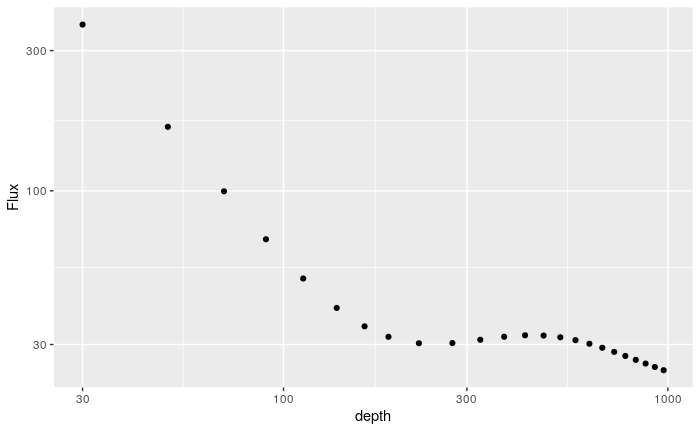

```r
Dsmooth42_sr02_All %>% #filter(DFP <= 1) %>%
  ggplot(aes(x = depth, y = Flux, 1)) + geom_point() +
  scale_x_log10() + scale_y_log10()
```

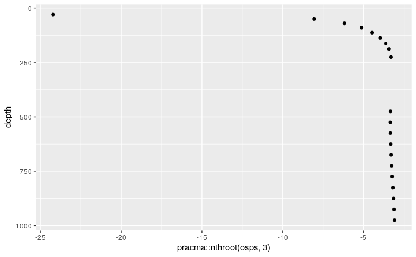

```r
Dsmooth42_sr02_All %>% filter(DFP <= 1) %>%
  ggplot(aes(y = depth, x = pracma::nthroot(osps, 3))) + geom_point() +
  scale_y_reverse()
```

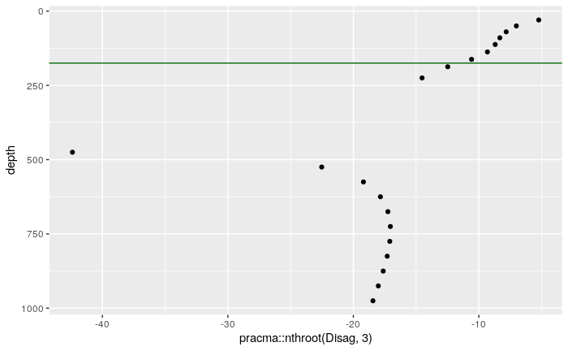

```r
Dsmooth42_sr02_All %>% filter(DFP <= 1) %>%
  ggplot(aes(y = depth, x = pracma::nthroot(Disag, 3))) + geom_point() + geom_hline(yintercept = 175, color = "darkgreen") +
  scale_y_reverse()
```

To do. * Finer bins. * Whole pipeline with different alpha and gamma params. Is this sensitive to those? * Dry and reproducable code * What is the particle size distribution of the new particles that is appearing in the mid water column and how do they compare to the particles that are appearing at the surface?

# Test time gam

```r
doubleGamAll <- ESS %>% my_double_gam()
summary(doubleGamAll)
```

```
Family: Negative Binomial(5.495)
Link function: log

Formula:
TotalParticles ~ s(log(lb), log(depth), by = factor(profile))

Parametric coefficients:
            Estimate Std. Error z value Pr(>|z|)
(Intercept)  -5.1422     0.1117  -46.04   <2e-16 ***
---
Signif. codes:  0 ‘***’ 0.001 ‘**’ 0.01 ‘*’ 0.05 ‘.’ 0.1 ‘ ’ 1

Approximate significance of smooth terms:
                                                edf Ref.df Chi.sq p-value
s(log(lb),log(depth)):factor(profile)p16n_100 18.02  20.78  14277  <2e-16 ***
s(log(lb),log(depth)):factor(profile)stn_032  19.43  22.05  14028  <2e-16 ***
s(log(lb),log(depth)):factor(profile)stn_035  20.27  22.55  10140  <2e-16 ***
s(log(lb),log(depth)):factor(profile)stn_036  23.17  25.28  11686  <2e-16 ***
s(log(lb),log(depth)):factor(profile)stn_037  21.73  24.04  11862  <2e-16 ***
s(log(lb),log(depth)):factor(profile)stn_038  19.31  21.92  11732  <2e-16 ***
s(log(lb),log(depth)):factor(profile)stn_039  22.14  24.22  13221  <2e-16 ***
s(log(lb),log(depth)):factor(profile)stn_040  19.18  21.80  11199  <2e-16 ***
s(log(lb),log(depth)):factor(profile)stn_042  15.49  18.45  10455  <2e-16 ***
s(log(lb),log(depth)):factor(profile)stn_043  21.37  23.69  14610  <2e-16 ***
---
Signif. codes:  0 ‘***’ 0.001 ‘**’ 0.01 ‘*’ 0.05 ‘.’ 0.1 ‘ ’ 1

R-sq.(adj) =  0.925   Deviance explained = 98.9%
-REML =  12201  Scale est. = 1         n = 4550
```

```r
AIC(doubleGamAll)
```

```
[1] 23904.89
```

```r
my_tripple_gam <- function(df){gam(TotalParticles ~s(log(lb), log(depth), as.numeric(time)), offset = log(vol * binsize), family = nb(), data = df)}
trippleGamAll <- ESS %>% my_tripple_gam()
```

```
Fitting terminated with step failure - check results carefully
```

```r
summary(trippleGamAll)
```

```
Family: Negative Binomial(1.718)
Link function: log

Formula:
TotalParticles ~ s(log(lb), log(depth), as.numeric(time))

Parametric coefficients:
            Estimate Std. Error z value Pr(>|z|)
(Intercept) -4.21554    0.04392  -95.99   <2e-16 ***
---
Signif. codes:  0 ‘***’ 0.001 ‘**’ 0.01 ‘*’ 0.05 ‘.’ 0.1 ‘ ’ 1

Approximate significance of smooth terms:
                                         edf Ref.df Chi.sq p-value
s(log(lb),log(depth),as.numeric(time)) 74.91  74.15  20198  <2e-16 ***
---
Signif. codes:  0 ‘***’ 0.001 ‘**’ 0.01 ‘*’ 0.05 ‘.’ 0.1 ‘ ’ 1

Rank: 102/110
R-sq.(adj) =  0.784   Deviance explained = 96.5%
-REML =  12364  Scale est. = 1         n = 4550
```

```r
AIC(trippleGamAll)
```

[output not shown]

```r
my_tripple_gam_2 <- function(df){gam(TotalParticles ~s(log(lb), log(depth)) + as.numeric(time), offset = log(vol * binsize), family = nb(), data = df)}
trippleGamAll2 <- ESS %>% my_tripple_gam_2()
summary(trippleGamAll2)
```

```
Family: Negative Binomial(1.894)
Link function: log

Formula:
TotalParticles ~ s(log(lb), log(depth)) + as.numeric(time)

Parametric coefficients:
                   Estimate Std. Error z value Pr(>|z|)
(Intercept)       6.378e+00  1.313e+00   4.856  1.2e-06 ***
as.numeric(time) -7.361e-09  8.874e-10  -8.294  < 2e-16 ***
---
Signif. codes:  0 ‘***’ 0.001 ‘**’ 0.01 ‘*’ 0.05 ‘.’ 0.1 ‘ ’ 1

Approximate significance of smooth terms:
                        edf Ref.df Chi.sq p-value
s(log(lb),log(depth)) 24.54  26.58  52115  <2e-16 ***
---
Signif. codes:  0 ‘***’ 0.001 ‘**’ 0.01 ‘*’ 0.05 ‘.’ 0.1 ‘ ’ 1

R-sq.(adj) =  0.671   Deviance explained = 96.7%
-REML =  13165  Scale est. = 1         n = 4550
```

```r
AIC(trippleGamAll2)
```

```
[1] 26219.02
```

```r
my_tripple_gam_2 <- function(df){gam(TotalParticles ~s(log(lb), log(depth)) + s(as.numeric(time)), offset = log(vol * binsize), family = nb(), data = df)}
trippleGamAll2 <- ESS %>% my_tripple_gam_2()
summary(trippleGamAll2)
```

```
Family: Negative Binomial(1.896)
Link function: log

Formula:
TotalParticles ~ s(log(lb), log(depth)) + s(as.numeric(time))

Parametric coefficients:
            Estimate Std. Error z value Pr(>|z|)
(Intercept)  -4.4953     0.1037  -43.34   <2e-16 ***
---
Signif. codes:  0 ‘***’ 0.001 ‘**’ 0.01 ‘*’ 0.05 ‘.’ 0.1 ‘ ’ 1

Approximate significance of smooth terms:
                         edf Ref.df   Chi.sq  p-value
s(log(lb),log(depth)) 24.550 26.586 52164.96  < 2e-16 ***
s(as.numeric(time))    1.713  1.921    76.44 7.27e-15 ***
---
Signif. codes:  0 ‘***’ 0.001 ‘**’ 0.01 ‘*’ 0.05 ‘.’ 0.1 ‘ ’ 1

R-sq.(adj) =  0.672   Deviance explained = 96.7%
-REML =  13148  Scale est. = 1         n = 4550
```

```r
AIC(trippleGamAll2)
```

```
[1] 26218.92
```

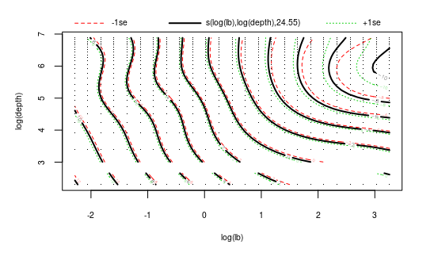

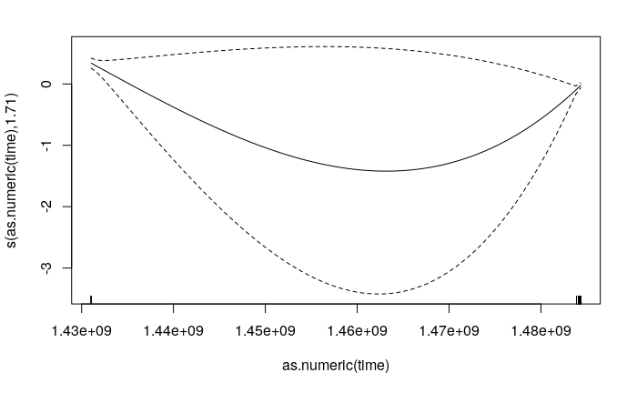

```r
plot(trippleGamAll2)
```

```r
my_tripple_gam_2 <- function(df){gam(TotalParticles ~s(log(lb), log(depth)) + as.factor(time), offset = log(vol * binsize), family = nb(), data = df)}
trippleGamAll2 <- ESS %>% my_tripple_gam_2()
summary(trippleGamAll2)
```

```
Family: Negative Binomial(1.943)
Link function: log

Formula:
TotalParticles ~ s(log(lb), log(depth)) + as.factor(time)

Parametric coefficients:
                                   Estimate Std. Error z value Pr(>|z|)
(Intercept)                        -4.16698    0.10950 -38.055  < 2e-16 ***
as.factor(time)2017-01-08 00:53:16 -0.49871    0.06011  -8.296  < 2e-16 ***
as.factor(time)2017-01-10 08:19:24 -0.46001    0.07409  -6.209 5.34e-10 ***
as.factor(time)2017-01-10 13:49:30 -0.45212    0.06809  -6.640 3.14e-11 ***
as.factor(time)2017-01-10 22:58:43 -0.39435    0.06798  -5.801 6.58e-09 ***
as.factor(time)2017-01-11 03:52:44 -0.26156    0.06774  -3.862 0.000113 ***
as.factor(time)2017-01-11 13:51:29  0.10761    0.06702   1.606 0.108364
as.factor(time)2017-01-12 05:00:27 -0.54349    0.06833  -7.954 1.81e-15 ***
as.factor(time)2017-01-12 18:55:07 -0.54847    0.06834  -8.026 1.01e-15 ***
as.factor(time)2017-01-13 11:51:31 -0.34943    0.05991  -5.833 5.45e-09 ***
---
Signif. codes:  0 ‘***’ 0.001 ‘**’ 0.01 ‘*’ 0.05 ‘.’ 0.1 ‘ ’ 1

Approximate significance of smooth terms:
                       edf Ref.df Chi.sq p-value
s(log(lb),log(depth)) 24.5  26.55  52864  <2e-16 ***
---
Signif. codes:  0 ‘***’ 0.001 ‘**’ 0.01 ‘*’ 0.05 ‘.’ 0.1 ‘ ’ 1

R-sq.(adj) =  0.678   Deviance explained = 96.9%
-REML =  13103  Scale est. = 1         n = 4550
```

```r
AIC(trippleGamAll2)
```

```
[1] 26115.52
```

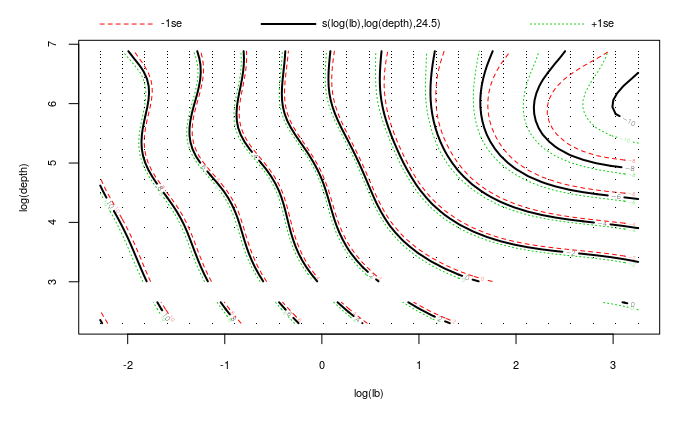

```r
plot(trippleGamAll2)
```

```r
time_to_hour <- function(tim){
  as.numeric(tim) %% 86400/3600
}

my_tripple_gam_cy <- function(df){gam(TotalParticles ~s(log(lb), log(depth)) + s(as.numeric(time)) + s(hour, bs = "cc"), offset = log(vol * binsize), knots = list(hour = c(0, 24)), family = nb(), data = df)}
trippleGamAllCy <- ESS %>% mutate(hour = time_to_hour(time)) %>% my_tripple_gam_cy()
summary(trippleGamAllCy)
```

```
Family: Negative Binomial(1.923)
Link function: log

Formula:
TotalParticles ~ s(log(lb), log(depth)) + s(as.numeric(time)) +
    s(hour, bs = "cc")

Parametric coefficients:
            Estimate Std. Error z value Pr(>|z|)
(Intercept)  -4.4962     0.1031  -43.63   <2e-16 ***
---
Signif. codes:  0 ‘***’ 0.001 ‘**’ 0.01 ‘*’ 0.05 ‘.’ 0.1 ‘ ’ 1

Approximate significance of smooth terms:
                         edf Ref.df   Chi.sq  p-value
s(log(lb),log(depth)) 24.519  26.56 52601.39  < 2e-16 ***
s(as.numeric(time))    1.000   1.00    59.27 1.38e-14 ***
s(hour)                5.909   8.00    56.03 3.98e-11 ***
---
Signif. codes:  0 ‘***’ 0.001 ‘**’ 0.01 ‘*’ 0.05 ‘.’ 0.1 ‘ ’ 1

R-sq.(adj) =  0.674   Deviance explained = 96.8%
-REML =  13134  Scale est. = 1         n = 4550
```

```r
AIC(trippleGamAllCy)
```

```
[1] 26177.24
```

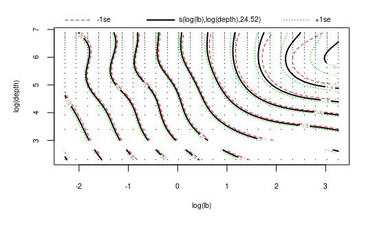

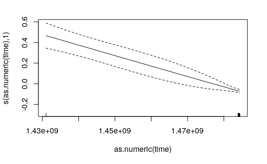

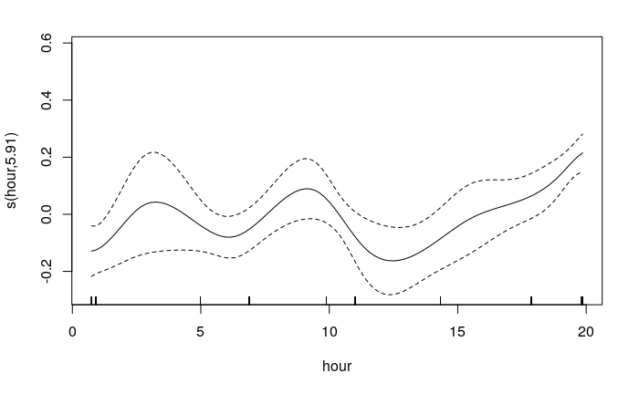

```r
plot(trippleGamAllCy)
```

```r
time_to_hour <- function(tim){
  as.numeric(tim) %% 86400/3600
}

my_tripple_gam_cy <- function(df){gam(TotalParticles ~s(log(lb), log(depth))  + s(hour, bs = "cc"), offset = log(vol * binsize), knots = list(hour = c(0, 24)), family = nb(), data = df)}
trippleGamAllCy <- ESS %>% mutate(hour = time_to_hour(time)) %>% my_tripple_gam_cy()
summary(trippleGamAllCy)
```

```
Family: Negative Binomial(1.856)
Link function: log

Formula:
TotalParticles ~ s(log(lb), log(depth)) + s(hour, bs = "cc")

Parametric coefficients:
            Estimate Std. Error z value Pr(>|z|)
(Intercept)  -4.4856     0.1029   -43.6   <2e-16 ***
---
Signif. codes:  0 ‘***’ 0.001 ‘**’ 0.01 ‘*’ 0.05 ‘.’ 0.1 ‘ ’ 1

Approximate significance of smooth terms:
                         edf Ref.df   Chi.sq  p-value
s(log(lb),log(depth)) 24.470  26.53 51496.97  < 2e-16 ***
s(hour)                4.504   8.00    60.88 1.52e-13 ***
---
Signif. codes:  0 ‘***’ 0.001 ‘**’ 0.01 ‘*’ 0.05 ‘.’ 0.1 ‘ ’ 1

R-sq.(adj) =  0.673   Deviance explained = 96.7%
-REML =  13158  Scale est. = 1         n = 4550
```

```r
AIC(trippleGamAllCy)
```

```
[1] 26236.17
```

2005 Pierson Model about zoop.